# Test a Perceptual Phenomenon

### Analyzing the Stroop Effect

Perform the analysis in the space below. Remember to follow [the instructions](https://docs.google.com/document/d/1-OkpZLjG_kX9J6LIQ5IltsqMzVWjh36QpnP2RYpVdPU/pub?embedded=True) and review the [project rubric](https://review.udacity.com/#!/rubrics/71/view) before submitting. Once you've completed the analysis and write up, download this file as a PDF or HTML file and submit in the next section.

(1) What is the independent variable? What is the dependent variable?

The indepednent variable is the congruence of the word.  
The dependent variable is the time taken to name the ink colors.

(2) What is an appropriate set of hypotheses for this task? What kind of statistical test do you expect to perform? Justify your choices.

Null hypothesis: the population means of time taken to name the ink colors for the congruent and incongruent words are the same.  
Alternative hypothesis: the population means of time taken to name the ink colors for the congruent and incongruent words are different.  
$H_o:\mu_{congrent}=\mu_{incongrent}$  
$H_1:\mu_{congrent}\neq\mu_{incongrent} $  
I will use the paired t-test to test the hypotheses because 1) the sample size was small (under 30); 2) the sample distrubituion is assumed normal; and 3) the measurements for the two groups were perfomed in pairs, meaning each subject was measured twice with two word groups.

(3) Report some descriptive statistics regarding this dataset. Include at least one measure of central tendency and at least one measure of variability. The name of the data file is 'stroopdata.csv'.

```python
# Perform the analysis here
import pandas as pd
import numpy as np
import matplotlib.pyplot as plt
%matplotlib inline
```

```python
df=pd.read_csv('stroopdata.csv')
df.head()
```

|  | Congruent | Incongruent |
| --- | --- | --- |
| 0 | 12.079 | 19.278 |
| 1 | 16.791 | 18.741 |
| 2 | 9.564 | 21.214 |
| 3 | 8.630 | 15.687 |
| 4 | 14.669 | 22.803 |

```python
df.info()
```

```
<class 'pandas.core.frame.DataFrame'>
RangeIndex: 24 entries, 0 to 23
Data columns (total 2 columns):
Congruent      24 non-null float64
Incongruent    24 non-null float64
dtypes: float64(2)
memory usage: 464.0 bytes
```

```python
df.describe()
```

|  | Congruent | Incongruent |
| --- | --- | --- |
| count | 24.000000 | 24.000000 |
| mean | 14.051125 | 22.015917 |
| std | 3.559358 | 4.797057 |
| min | 8.630000 | 15.687000 |
| 25% | 11.895250 | 18.716750 |
| 50% | 14.356500 | 21.017500 |
| 75% | 16.200750 | 24.051500 |
| max | 22.328000 | 35.255000 |

For the congruent word group, the mean of the time taken is 14.05s, the standard deviation of the time taken is 3.56s, and the median of the time taken is 14.36s.  
For the incongruent word group, the mean of the time taken is 22.02s, the standard deviation of the time take is 4.80s, and the median of the time taken is 21.02s.  
When comparing the two groups, the average time taken to name the ink colors of the incongruent word group is longer than that of the congruent word group, and the variation of time taken of the incongruent word group is larger than that of the congruent word group.

(4) Provide one or two visualizations that show the distribution of the sample data. Write one or two sentences noting what you observe about the plot or plots.

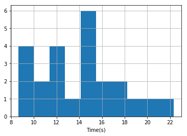

```python
# Build the visualizations here
df['Congruent'].hist();
plt.xlabel('Time(s)');
```

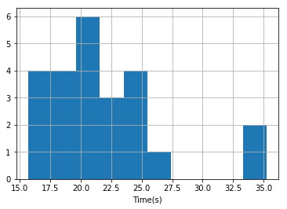

```python
df['Incongruent'].hist();
plt.xlabel('Time(s)');
```

The sample distrubitions for both groups are both skewed to the right.  
However, the center of the distrubution for the Congrent word group is around 15s, and the center of the distribution of the Incongruent word goupr is around 20s.

(5) Now, perform the statistical test and report the results. What is the confidence level and your critical statistic value? Do you reject the null hypothesis or fail to reject it? Come to a conclusion in terms of the experiment task. Did the results match up with your expectations?

```python
# Perform the statistical test here
from scipy import stats
stats.ttest_rel(df.Congruent,df.Incongruent)
```

```
Ttest_relResult(statistic=-8.020706944109957, pvalue=4.1030005857111781e-08)
```